# Peer Assessment I

First, let us load the data and necessary packages:

```r
setwd("C:/Users/Kevin/Documents/Coursera Files/Duke_Statistics_R/Capstone/PeerReview_Proj1")
load("ames_train.Rdata")
library(MASS)
library(dplyr)
library(ggplot2)
```

# 1

Make a labeled histogram (with 30 bins) of the ages of the houses in the data set, and describe the distribution.

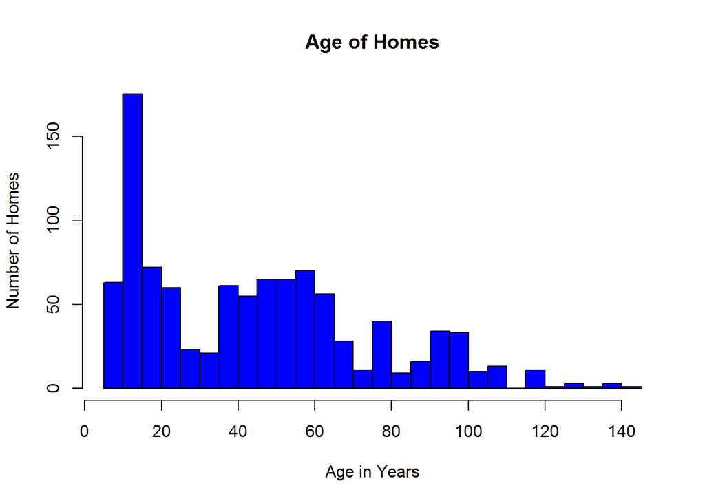

```r
# type your code for Question 1 here, and Knit
ames_train$age_of_home <- (as.numeric(format(Sys.Date(), "%Y")) - ames_train$Year.Built)
hist(ames_train$age_of_home, breaks = 30, ylab = 'Number of Homes', xlab = 'Age in Years', main = 'Age of Homes', col = 'blue')
```

The distribution is right skewed, and can be described as bi-modal. There are significant numbers of homes in the 0-20 year old range, as well as the 35-65 year old range. The median age is 42, mean age of 44.8, with minimum age 7 and maximum age 145.

# 2

The mantra in real estate is “Location, Location, Location!” Make a graphical display that relates a home price to its neighborhood in Ames, Iowa. Which summary statistics are most appropriate to use for determining the most expensive, least expensive, and most heterogeneous (having the most variation in housing price) neighborhoods? Report which neighborhoods these are based on the summary statistics of your choice. Report the value of your chosen summary statistics for these neighborhoods.

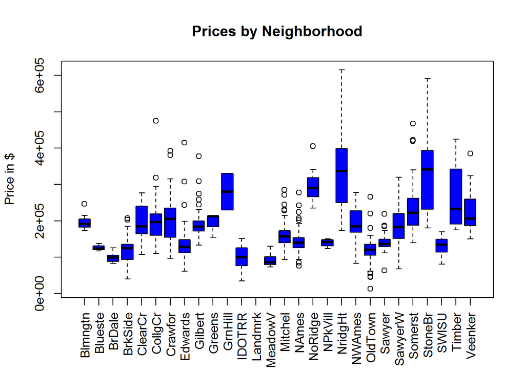

```r
# boxplots for viz and median/sd for measures of central tendency and spread
boxplot(ames_train$price ~ ames_train$Neighborhood, ylab = 'Price in $', main = 'Prices by Neighborhood', par(las = 3), col = 'blue')
```

```r
#Group data by 'hood and generate summary stats of interest
ames_by_neighborhood <- group_by(ames_train, Neighborhood)
summary_price_stats <- summarise(ames_by_neighborhood, median(price), mean(price), sd(price))

#Select the lowest median price neighborhood
summary_price_stats[summary_price_stats$`median(price)` == min(summary_price_stats$`median(price)`) , c(1,2)]
```

```
## # A tibble: 1 × 2
##   Neighborhood `median(price)`
##         <fctr>           <dbl>
## 1      MeadowV           85750
```

```r
#Select the highest median price neighborhood
summary_price_stats[summary_price_stats$`median(price)` == max(summary_price_stats$`median(price)`) , c(1,2)]
```

```
## # A tibble: 1 × 2
##   Neighborhood `median(price)`
##         <fctr>           <dbl>
## 1      StoneBr        340691.5
```

```r
#Select the highest standard deviation of price neighborhood
summary_price_stats[summary_price_stats$`sd(price)` == max(summary_price_stats$`sd(price)`) , c(1,4)]
```

```
## # A tibble: 1 × 2
##   Neighborhood `sd(price)`
##         <fctr>       <dbl>
## 1      StoneBr    123459.1
```

Appropriate summary statistics for:

- determining most/last expensive neighborhood is median (to avoid skew from the use of a mean)
- determining the most heterogeneous neighborhood is standard deviation (to get a sense of spread)

As seen in the displays above, Meadowv has the lowest median home price at 85750 Dollars, StoneBr has the highest median home price at 340691.5 Dollars, and StoneBr also has the most heterogeneous pricing with a standard deviation of 123459.1 Dollars.

# 3

Which variable has the largest number of missing values? Explain why it makes sense that there are so many missing values for this variable.

```r
# Finding the variable with the most NA values, and how counting how many values there are
counting_NAs_List <- apply(ames_train, 2, function(x) {sum(is.na(x))} )
counting_NAs_List[which(counting_NAs_List == max(counting_NAs_List))]
```

```
## Pool.QC
##     997
```

The variable “Pool.QC”, representing a quality rating for a swimming pool, has the most actual NA values. This is logical, as pools are expensive and relatively infrequent home features.

A side note - a pure NA check (as it seems the instructors request) neglects that quantitative variables with a value of 0 are effective NAs. Further work might examine this possibility when assessing data completeness for prediction.

# 4

We want to predict the natural log of the home prices. Candidate explanatory variables are lot size in square feet (Lot.Area), slope of property (Land.Slope), original construction date (Year.Built), remodel date (Year.Remod.Add), and the number of bedrooms above grade (Bedroom.AbvGr). Pick a model selection or model averaging method covered in the Specialization, and describe how this method works. Then, use this method to find the best multiple regression model for predicting the natural log of the home prices.

```r
# Tidy up a new frame with just cols needed - transform vars, etc.
pred_ames_train <- ames_train[,c('price','Lot.Area','Land.Slope','Year.Built','Year.Remod.Add', 'Bedroom.AbvGr')]
pred_ames_train$log_price <- log(pred_ames_train$price)
pred_ames_train$price <- NULL
#pred_ames_train$Year.Built <- as.factor(pred_ames_train$Year.Built)
#pred_ames_train$Year.Built <- as.factor(pred_ames_train$Year.Remod.Add)

# Stepwise AIC backwards selection
lm_initial <- lm(log_price ~ ., data = pred_ames_train)
final_lm <- stepAIC(lm_initial, direction = c('backward'))
```

```
## Start:  AIC=-2545.77
## log_price ~ Lot.Area + Land.Slope + Year.Built + Year.Remod.Add +
##     Bedroom.AbvGr
##
##                  Df Sum of Sq    RSS     AIC
## <none>                        77.322 -2545.8
## - Land.Slope      2    1.4281 78.750 -2531.5
## - Bedroom.AbvGr   1    5.0628 82.385 -2484.3
## - Lot.Area        1    6.7292 84.051 -2464.3
## - Year.Remod.Add  1   11.9642 89.286 -2403.9
## - Year.Built      1   19.8546 97.177 -2319.2
```

```r
summary(final_lm)
```

```
##
## Call:
## lm(formula = log_price ~ Lot.Area + Land.Slope + Year.Built +
##     Year.Remod.Add + Bedroom.AbvGr, data = pred_ames_train)
##
## Residuals:
##     Min      1Q  Median      3Q     Max
## -2.0878 -0.1651 -0.0211  0.1657  0.9945
##
## Coefficients:
##                  Estimate Std. Error t value Pr(>|t|)
## (Intercept)    -1.371e+01  8.574e-01 -15.996  < 2e-16 ***
## Lot.Area        1.028e-05  1.106e-06   9.296  < 2e-16 ***
## Land.SlopeMod   1.384e-01  4.991e-02   2.773  0.00565 **
## Land.SlopeSev  -4.567e-01  1.514e-01  -3.016  0.00263 **
## Year.Built      6.049e-03  3.788e-04  15.968  < 2e-16 ***
## Year.Remod.Add  6.778e-03  5.468e-04  12.395  < 2e-16 ***
## Bedroom.AbvGr   8.686e-02  1.077e-02   8.063 2.12e-15 ***
## ---
## Signif. codes:  0 '***' 0.001 '**' 0.01 '*' 0.05 '.' 0.1 ' ' 1
##
## Residual standard error: 0.279 on 993 degrees of freedom
## Multiple R-squared:  0.5625, Adjusted R-squared:  0.5598
## F-statistic: 212.8 on 6 and 993 DF,  p-value: < 2.2e-16
```

The AIC model selection method balances a penalty for more explanatory vars (similar to adusted R^2 vs pure R^2) while trying to maximize “goodness of fit” via a likelihood function.

Details of the best model are available in the above summary readout, including variables, coefficients, statistical significance, R^2, etc.

# 5

Which home has the largest squared residual in the previous analysis (Question 4)? Looking at all the variables in the data set, can you explain why this home stands out from the rest (what factors contribute to the high squared residual and why are those factors relevant)?

```r
# Return the maximum squared residual value
max(final_lm$residuals^2)
```

```
## [1] 4.35913
```

```r
# Return the index position and actual non-squared residual value
final_lm$residuals[which.max(final_lm$residuals^2)]
```

```
##       428
## -2.087853
```

```r
# Return the full record for that index position (i.e. home with the highest squared residual)
ames_train[which.max(final_lm$residuals^2),]
```

```
## # A tibble: 1 × 82
##         PID  area price MS.SubClass MS.Zoning Lot.Frontage Lot.Area Street
##       <int> <int> <int>       <int>    <fctr>        <int>    <int> <fctr>
## 1 902207130   832 12789          30        RM           68     9656   Pave
## # ... with 74 more variables: Alley <fctr>, Lot.Shape <fctr>,
## #   Land.Contour <fctr>, Utilities <fctr>, Lot.Config <fctr>,
## #   Land.Slope <fctr>, Neighborhood <fctr>, Condition.1 <fctr>,
## #   Condition.2 <fctr>, Bldg.Type <fctr>, House.Style <fctr>,
## #   Overall.Qual <int>, Overall.Cond <int>, Year.Built <int>,
## #   Year.Remod.Add <int>, Roof.Style <fctr>, Roof.Matl <fctr>,
## #   Exterior.1st <fctr>, Exterior.2nd <fctr>, Mas.Vnr.Type <fctr>,
## #   Mas.Vnr.Area <int>, Exter.Qual <fctr>, Exter.Cond <fctr>,
## #   Foundation <fctr>, Bsmt.Qual <fctr>, Bsmt.Cond <fctr>,
## #   Bsmt.Exposure <fctr>, BsmtFin.Type.1 <fctr>, BsmtFin.SF.1 <int>,
## #   BsmtFin.Type.2 <fctr>, BsmtFin.SF.2 <int>, Bsmt.Unf.SF <int>,
## #   Total.Bsmt.SF <int>, Heating <fctr>, Heating.QC <fctr>,
## #   Central.Air <fctr>, Electrical <fctr>, X1st.Flr.SF <int>,
## #   X2nd.Flr.SF <int>, Low.Qual.Fin.SF <int>, Bsmt.Full.Bath <int>,
## #   Bsmt.Half.Bath <int>, Full.Bath <int>, Half.Bath <int>,
## #   Bedroom.AbvGr <int>, Kitchen.AbvGr <int>, Kitchen.Qual <fctr>,
## #   TotRms.AbvGrd <int>, Functional <fctr>, Fireplaces <int>,
## #   Fireplace.Qu <fctr>, Garage.Type <fctr>, Garage.Yr.Blt <int>,
## #   Garage.Finish <fctr>, Garage.Cars <int>, Garage.Area <int>,
## #   Garage.Qual <fctr>, Garage.Cond <fctr>, Paved.Drive <fctr>,
## #   Wood.Deck.SF <int>, Open.Porch.SF <int>, Enclosed.Porch <int>,
## #   X3Ssn.Porch <int>, Screen.Porch <int>, Pool.Area <int>,
## #   Pool.QC <fctr>, Fence <fctr>, Misc.Feature <fctr>, Misc.Val <int>,
## #   Mo.Sold <int>, Yr.Sold <int>, Sale.Type <fctr>, Sale.Condition <fctr>,
## #   age_of_home <dbl>
```

The identified home has a residual of -2.087, with squared residual of 4.359 which is the maximum of any home. Likely reasons this home’s value is so far from (in this case below) the model projection include: lower than average sq ft area, relatively old construction (1923), abnormal sale conditions (e.g. a forclosure), no basement, 1 story home, etc. These characteristics lower the value proposition to a potential buyer, relative to the other options in the market, and would contribute to a lower sale price.

# 6

Use the same model selection method you chose in Question 4 to again find the best multiple regression model to predict the natural log of home prices, but this time **replacing Lot.Area with log(Lot.Area)**. Do you arrive at a model including the same set of predictors?

```r
# copy the previous data set
pred_ames_train_logLotArea <- pred_ames_train
#Transform the lot area var to log of lot area, then remove the old column
pred_ames_train_logLotArea$Log.Lot.Area <- log(pred_ames_train_logLotArea$Lot.Area)
pred_ames_train_logLotArea$Lot.Area <- NULL
#Create an initial lm and then use backward AIC to find and return summary of best lm
lm_initial_LogLotArea <- lm(log_price ~ . , data = pred_ames_train_logLotArea)
final_lm_LogLotArea <- stepAIC(lm_initial_LogLotArea, direction = c('backward'))
```

```
## Start:  AIC=-2649.5
## log_price ~ Land.Slope + Year.Built + Year.Remod.Add + Bedroom.AbvGr +
##     Log.Lot.Area
##
##                  Df Sum of Sq    RSS     AIC
## <none>                        69.704 -2649.5
## - Land.Slope      2    0.4429 70.147 -2647.2
## - Bedroom.AbvGr   1    2.2002 71.904 -2620.4
## - Year.Remod.Add  1   11.8182 81.522 -2494.9
## - Log.Lot.Area    1   14.3474 84.051 -2464.3
## - Year.Built      1   19.4083 89.112 -2405.9
```

```r
summary(final_lm_LogLotArea)
```

```
##
## Call:
## lm(formula = log_price ~ Land.Slope + Year.Built + Year.Remod.Add +
##     Bedroom.AbvGr + Log.Lot.Area, data = pred_ames_train_logLotArea)
##
## Residuals:
##      Min       1Q   Median       3Q      Max
## -2.14050 -0.15650 -0.01561  0.15350  0.90854
##
## Coefficients:
##                  Estimate Std. Error t value Pr(>|t|)
## (Intercept)    -1.553e+01  8.197e-01 -18.947  < 2e-16 ***
## Land.SlopeMod   1.151e-01  4.734e-02   2.431   0.0152 *
## Land.SlopeSev  -6.554e-02  1.222e-01  -0.536   0.5917
## Year.Built      5.981e-03  3.597e-04  16.628  < 2e-16 ***
## Year.Remod.Add  6.734e-03  5.190e-04  12.975  < 2e-16 ***
## Bedroom.AbvGr   5.909e-02  1.055e-02   5.599  2.8e-08 ***
## Log.Lot.Area    2.442e-01  1.708e-02  14.297  < 2e-16 ***
## ---
## Signif. codes:  0 '***' 0.001 '**' 0.01 '*' 0.05 '.' 0.1 ' ' 1
##
## Residual standard error: 0.2649 on 993 degrees of freedom
## Multiple R-squared:  0.6056, Adjusted R-squared:  0.6032
## F-statistic: 254.1 on 6 and 993 DF,  p-value: < 2.2e-16
```

Yes, this arrived at a MLR model with the same explanatory variables. However, there were some differences in the result:

- A ~4% higher adjusted R^2 (proportion of variation in response that is explained by the model.)
- Statistical significance of the overall model is the same, but the factor variable Land.Slope has several levels, all of which have less statistical significance to this model than the previous.

# 7

Do you think it is better to log transform Lot.Area, in terms of assumptions for linear regression? Make graphs of the predicted values of log home price versus the true values of log home price for the regression models selected for Lot.Area and log(Lot.Area). Referencing these two plots, provide a written support that includes a quantitative justification for your answer in the first part of question 7.

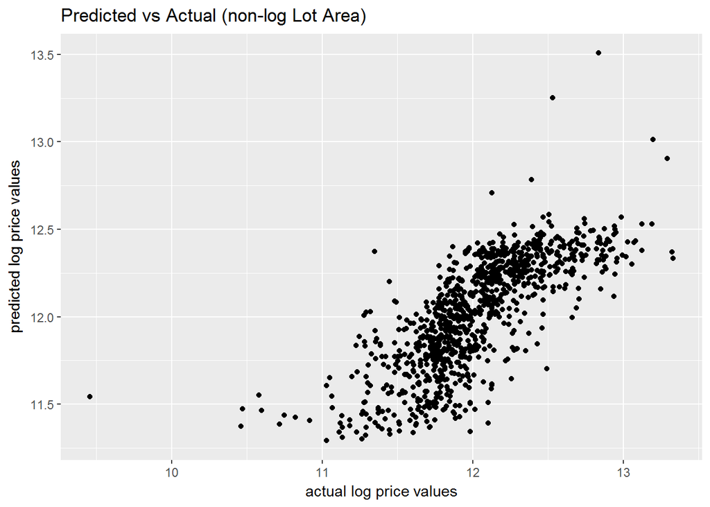

```r
# Diagnostics plots + the predicted vs actual plot requested by staff

#Staff request for predicted vs actual log price
  qplot(pred_ames_train$log_price, final_lm$fitted.values, xlab = 'actual log price values', ylab = 'predicted log price values', main = 'Predicted vs Actual (non-log Lot Area)')
```

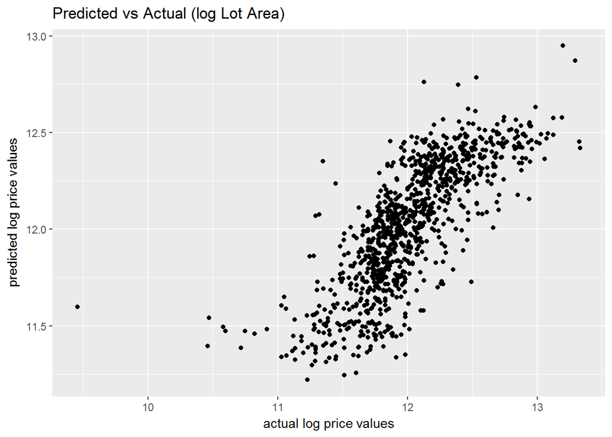

```r
    #l1 <- lm(pred_ames_train$log_price ~ final_lm$fitted.values)
  qplot(pred_ames_train_logLotArea$log_price, final_lm_LogLotArea$fitted.values, xlab = 'actual log price values', ylab = 'predicted log price values', main = 'Predicted vs Actual (log Lot Area)')
```

```r
    #l2 <- lm(pred_ames_train_logLotArea$log_price ~ final_lm_LogLotArea$fitted.values)

#Linear relationship check
  #qplot(pred_ames_train$log_price, final_lm$residuals)
  #qplot(pred_ames_train_logLotArea$log_price, final_lm_LogLotArea$residuals)

#Normalcy of residuals check
  #qplot(final_lm$residuals)
  #qplot(final_lm_LogLotArea$residuals)

#Variability of Residuals check
  #qplot(final_lm$fitted.values, final_lm$residuals)
  #qplot(final_lm_LogLotArea$fitted.values, final_lm_LogLotArea$residuals)
```

The log of lot size acts to further linearize the results of the model predictions vs log price. This can be confirmed through examining R^2 values when fitting a model on these two variables. We have ~4% better linear explanation with log lot size in the mix. By eye, we can see that a slightly more linear relationship exists in the second graph (with log lot size as an explanatory variable).

Other diagnostics, such as normality and variation of residuals, can help confirm this. See my commented code for an example.